# OASIS - Optimized Adaptive Statistic for Inferring Structure - Summary

[Francois Collin](https://www.linkedin.com/in/francoisz/)

November 18, 2025

## Outline

# 1 Data Description

## Data Files

- At the raw data level, samples are represented by separate sequencing data (FASTQ files).
- The goal of SPLASH is to detect sequence variation between the samples of a set.
  - The goal is to interrogate the read counts in order to distinghish two scenarios: - 1. the reads for all samples were generated by a common source. eg the same biological units, or units from the same group. - 2. the reads for the samples were generated by more than one source.

## Raw Data

- To detect variation (in the sense of genomic sequence differences between samples) a set of **anchors** - k-mers which appear among the reads - are identified and combined into a set.
- A set of **targets** - k-mers which appear among the reads at locations a few loci down from the anchors - is also compiled.
- The anchors and targets associated with each sample will be considered the raw data.

# 2 OASIS: Problem Formulation

- There are several ways to address the question of interest - are the samples meaningfully different in terms of genomic sequence characteristics captured by the anchor & targets patterns.
- OASIS chooses to formulate the problem as one of the identification of anchors for which the **conditional distributions of target counts given the total number of targets** found for each sample anchor are not independent.
- In this formulation of the problem, a sufficient set of statistics are the target counts for each sample anchor and OASIS reduces the data to a contingency table for each anchor: the rows are targets, the columns samples, the entries are target counts.
- $X \in \mathbb{N}^{I \times J}, \: X_{ij} = \text{Total number of sample j anchor reads with target i}$
- In this work, we focus on the case where the
  - **columns correspond to biological samples** (explanatory random variable) and
  - the **rows correspond to the response variable (targets)**.
- Thus, the OASIS formulation of the problem asks whether the columnwise conditional row distribution is the same for each column.
- Define $X^{(j)}$ as the $j$-th column of $X$, and
- $n_j = \sum_{i=1}^{I} X_{ij}$ as the total number of counts in column $j$.
- Let $M = \sum_j n_j$ be the total number of counts in the table, equivalently obtainable by summing row or column sums.

We consider the following model:

**Definition 1 (Null Model).**
(Conditional on | Given)[^1] the column totals $\{n_j\}_{j=1}^{J}$, each column of the contingency table $X$ is
$$X^{(j)} \sim \text{multinomial}(n_j, p),$$
drawn independently for all $j$, for some common vector of (unknown) row probabilities $p$.

# 3 OASIS Test Statistic

## 3.1 Calculation

- The OASIS test statistic provides a linear algebraic approach for testing deviations in contingency tables.
- It evaluates whether the observed data can be significantly partitioned according to embedding vectors $f \in \mathbb{R}^I$ (rows) and $c \in \mathbb{R}^J$ (columns).
  - These embeddings can be chosen through optimization, or using metadata.

Given an observed contingency table $X \in \mathbb{N}^{I \times J}$, define:

- The **expected matrix** $E \in \mathbb{R}^{I \times J}$:
  $$E = \frac{1}{M}X \mathbf{1}\mathbf{1}^\top X,$$
- The **centered and normalized table** $\tilde{X} \in \mathbb{R}^{I \times J}$:
  $$\tilde{X} = (X - E)\,\text{diag}\left(1 \,/\, \sqrt{X^\top \mathbf{1}}\right),$$
- The **OASIS test statistic** $S$:
  $$S = S(f,c) = f^\top \tilde{X} c.$$

## 3.2 **Optimization**: $f$, $c$:

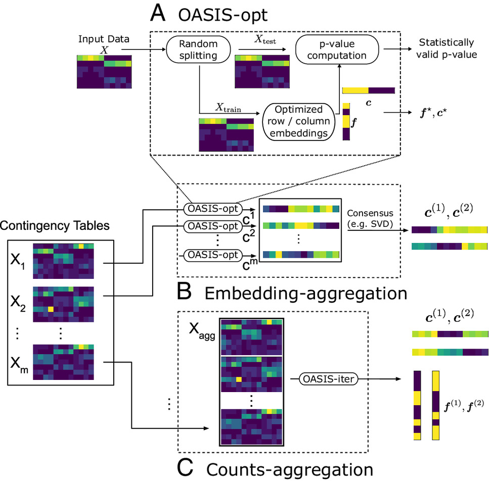

# 4 SVD vs OASIS: Mathematical Objectives Comparison

## 4.1 The Two Optimization Objectives

From Section S.3.E of the OASIS supplementary materials (Baharav, Tse, and Salzman):

### 4.1.1 SVD Objective

The Singular Value Decomposition (SVD) computes:

$$\mathop{\mathrm{arg\,max}}_{c, f} \frac{f^{\top} \tilde{X} c}{\|f\|_2 \|c\|_2}$$

### 4.1.2 OASIS p-value Bound Objective

In contrast, OASIS optimizes the p-value bound by computing:

$$\mathop{\mathrm{arg\,max}}_{c, f} \frac{f^{\top} \tilde{X} c}{\|f\|_{\infty} \|c\|_2}$$

## 4.2 The Key Difference

**The only difference is in how $f$ is normalized:**

- **SVD uses:** $\|f\|_2 = \sqrt{\sum_i f_i^2}$ (Euclidean/L2 norm)
- **OASIS uses:** $\|f\|_{\infty} = \max_i |f_i|$ (maximum/L-infinity norm)

Both use $\|c\|_2$ for the column vector $c$.

## 4.3 What This Means

### 4.3.1 Notation

- $\tilde{X}$ is the centered and normalized contingency table
- $f$ is the row embedding vector (weights for rows/features)
- $c$ is the column embedding vector (weights for samples)
- $f^{\top} \tilde{X} c$ is the test statistic (a bilinear form)

### 4.3.2 SVD Interpretation

$$\frac{f^{\top} \tilde{X} c}{\|f\|_2 \|c\|_2}$$

- Maximizes the correlation-like quantity between rows and columns
- Penalizes $f$ based on its **total squared magnitude**
- Encourages $f$ to distribute weight across multiple rows
- **Effect:** Finds principal directions capturing the most variance
- This is equivalent to finding the largest singular value

### 4.3.3 OASIS Interpretation

$$\frac{f^{\top} \tilde{X} c}{\|f\|_{\infty} \|c\|_2}$$

- Maximizes the same numerator (test statistic)
- Penalizes $f$ based only on its **largest element**
- **Does not penalize** spreading weight across many rows (as long as max is controlled)
- **Effect:** Can put weight on many rows simultaneously
- This leads to the p-value bound via Hoeffding’s inequality

## 4.4 Why OASIS Uses $\|f\|_{\infty}$

### 4.4.1 The Statistical Reason

From the OASIS paper, the test statistic is:

$$T = f^{\top} \tilde{X} c = \sum_{i,j} f_i \tilde{X}_{ij} c_j$$

Under the null hypothesis, $\tilde{X}_{ij}$ are (approximately) independent random variables.

**Hoeffding’s inequality** bounds the probability that a weighted sum of bounded random variables deviates from its mean. The bound depends on:  
- The range of each random variable - The **maximum weight** (not the sum of squared weights)

**Key insight:** For concentration inequalities, what matters is $\max_i |f_i|$, not $\sqrt{\sum_i f_i^2}$.

### 4.4.2 The Mathematical Connection

**Hoeffding’s bound:** If $X_1, \ldots, X_n$ are independent with $X_i \in [a_i, b_i]$ and $\sum_i w_i X_i$ is their weighted sum, then:

$$P\left(\left|\sum_i w_i X_i - \mathbb{E}\left[\sum_i w_i X_i\right]\right| \geq t\right) \leq 2\exp\left(\frac{-2t^2}{\sum_i w_i^2(b_i - a_i)^2}\right)$$

For OASIS’s setup:

- Want to bound $P(f^{\top} \tilde{X} c \geq t)$
- The bound involves $\sum_i f_i^2 \times (\text{range})^2$
- With appropriate normalization, this becomes $\|f\|_{\infty}^2$

**Therefore:** The $\|f\|_{\infty}$ term in the denominator is **exactly what appears in the p-value bound**, not an arbitrary choice.

## 4.5 Practical Implications

### 4.5.1 SVD Behavior

When you maximize $\frac{f^{\top} \tilde{X} c}{\|f\|_2 \|c\|_2}$:

**Example:** Suppose you have two rows with signal: - Row 1 has moderate correlation with column pattern - Row 2 has moderate correlation with column pattern

**SVD solution:** Put weight on both rows (e.g., $f_1 = f_2 = 0.707$)Q

- Numerator: Gets contribution from both rows
- Denominator: $\|f\|_2 = \sqrt{0.707^2 + 0.707^2} = 1$
- **Combines signal from multiple rows**

### 4.5.2 OASIS Behavior

When you maximize $\frac{f^{\top} \tilde{X} c}{\|f\|_{\infty} \|c\|_2}$:

**Same example:**

**OASIS solution:** Put weight on both rows (e.g., $f_1 = f_2 = 1$)

**Key difference:** OASIS is not penalized for using many rows (as long as no single weight is too large), while SVD is penalized by the sum of squares.

## 4.6 The Trade-off

### 4.6.1 SVD Advantages

- **Variance maximization:** Finds directions explaining most variation
- **Orthogonal decomposition:** Subsequent components are uncorrelated
- **Well-understood:** Decades of theory and practice
- **Stable:** Small data changes → small solution changes

### 4.6.2 OASIS Advantages

- **Statistical validity:** P-value bound is mathematically justified
- **Sparse-data robustness:** $\|f\|_{\infty}$ term handles low counts better
- **Interpretability (claimed):** Binary $f$ for clustering
- **Focused power:** Can concentrate on specific row patterns

### 4.6.4 OASIS Disadvantages

- **Computational complexity:** $\|f\|_{\infty}$ constraint makes optimization harder (NP-hard)
- **Local optima:** Alternating maximization doesn’t guarantee global optimum
- **Data splitting:** Uses train/test split, throwing away half the data
- **Limited theory:** Asymptotic properties less developed than SVD

## 4.7 A Critical Perspective

### 4.7.1 Is This Really Better?

**The claim:** OASIS provides “statistically valid” p-values while SVD doesn’t.

**The reality:**

1. **Both are fitting a model to high-dimensional data** (K rows, N columns)
2. **Both involve optimization** that may not find the global optimum
3. **Both make assumptions** (independence, distributional forms)
4. **OASIS adds data splitting** (train/test), which reduces power

**The question:** When K is in the thousands and N is in the tens:

- Is an “exact finite-sample p-value” more trustworthy than SVD’s eigenvalue?
- Or have both methods entered the “complex model fit to sparse data” regime?

### 4.7.2 The Optimization Problem

Both objectives try to maximize $f^{\top} \tilde{X} c$, just with different normalization.

**But:** With K rows and N columns:

- There are $2^K$ possible binary vectors $f$ (if restricting to {-1, 1})
- Finding the optimal $f$ is **NP-hard** for both formulations
- **In practice:** Use greedy algorithms (alternating maximization)
- **Result:** You get a local optimum, not the global optimum

**Implication:** The “exact p-value” is for **the $f$ you found**, not the optimal $f$. This introduces unquantified uncertainty.

## 4.8 When Does the Difference Matter?

### 4.8.1 Scenario 1: Strong Signal in Few Rows

**Setup:** 2-3 rows have strong signal, rest are noise

**SVD:** Puts most weight on those 2-3 rows, some weight on noise rows (due to L2 penalty)

**OASIS:** Puts weight primarily on those 2-3 rows (L∞ doesn’t penalize this)

**Winner:** OASIS might have slightly better power (but probably small difference)

### 4.8.2 Scenario 2: Diffuse Signal Across Many Rows

**Setup:** 50 rows each have weak signal

**SVD:** Spreads weight across all 50 rows, captures cumulative signal

**OASIS:** Can also spread weight across 50 rows (no penalty from L∞ as long as weights are similar)

**Winner:** Similar performance, but SVD has cleaner interpretation

### 4.8.3 Scenario 3: Sparse Contingency Table

**Setup:** Many cells with zero or small counts

**SVD:** Standardization by $\sqrt{\sum_i f_i^2}$ can amplify noise in low-count rows

**OASIS:** Standardization by $\max_i |f_i|$ is more conservative

**Winner:** OASIS may be more robust (this is the claimed advantage)

## 4.9 The Bottom Line

### 4.9.1 Mathematical Perspective

The difference between $\|f\|_2$ and $\|f\|_{\infty}$ reflects:

- **SVD:** Variance decomposition framework
- **OASIS:** Concentration inequality framework

These are genuinely different mathematical approaches.

### 4.9.2 Statistical Perspective

The key question is: **Does the framework matter when K is large and N is small?**

**Arguments for “No”:**

1. Both involve optimization that finds local optima
2. Both fit complex models to sparse data
3. Both make distributional assumptions that are approximate
4. OASIS throws away half the data (train/test split)
5. In high dimensions, the distinction between “exact p-value” and “useful approximation” becomes philosophical

**Arguments for “Yes”:**

1. Having a p-value bound (even approximate) is better than no p-value
2. Concentration inequalities provide interpretable guarantees
3. Robustness to sparse data is valuable
4. The $\|f\|_{\infty}$ normalization is mathematically justified by Hoeffding

### 4.9.3 Practical Perspective

**For most genomics applications:**

- Prediction accuracy and biological validation matter more than exact p-values
- Replication in independent cohorts is the gold standard
- Whether you use SVD or OASIS is less important than:
  - Quality of data
  - Appropriate preprocessing
  - Biological interpretation
  - Independent validation

**OASIS’s real contribution may be:**

- Not the p-value itself
- But rather: A different way to think about matrix decomposition
- That happens to be more robust to sparsity
- And provides a statistical framework (even if approximate)

## 4.10 Conclusion

The mathematical difference between SVD and OASIS is clear and principled:

$$\text{SVD: } \|f\|_2 \quad \text{vs.} \quad \text{OASIS: } \|f\|_{\infty}$$

This difference:

- **Is mathematically justified** (Hoeffding’s inequality requires $\|f\|_{\infty}$)
- **May provide practical benefits** (robustness to sparsity)
- **Enables p-value bounds** (unlike SVD)

But in the context of genomics with K >> N:

- **Both methods enter the “complex model” regime**
- **Both make approximations**
- **Both have limitations**
- **The “exact” p-value may be illusory** (due to optimization, data splitting, assumptions)

The deeper question remains: **In high-dimensional genomics, is optimizing for statistical validity (exact p-values) the right goal, or have we entered a regime where prediction, robustness, and biological interpretation matter more?**

## 4.11 References

1. Baharav, T.Z., Tse, D., and Salzman, J. (2024). “OASIS: An interpretable, finite-sample valid alternative to Pearson’s X² for scientific discovery.” *PNAS* 121(15). Supplementary Section S.3.E.
2. Hoeffding, W. (1963). “Probability inequalities for sums of bounded random variables.” *Journal of the American Statistical Association* 58(301): 13-30.
3. Eckart, C. and Young, G. (1936). “The approximation of one matrix by another of lower rank.” *Psychometrika* 1(3): 211-218. [Original SVD paper]

# 5 Appendix

## Analysis of Random Variability

- Any model for the data in the analysis dataset must take full account of all of the sources of variability.
  - we repeat a measurement under the same conditions and get different results, that’s variability
  - the data of interest in this case are the anchor and target sequences which can be read off of the reads
  - *all variability in this dataset* come from the **selection of fastq files**
    - fastq sample
  - each fastq contains a set of reads which can be considered a simple random sample from a **population of reads**.
    - the **population of reads** can be thought of as being the observed reads set in the case of unlimited sequencing depth.
  - when we compare the data from 2 fastq files, we are comparing two samples from two populations
    - the difference between any two populations is a function of the differences in samples processing:
      - repeats are resequencing runs of a unique library or prepared samples
        - repeats only capture sequencing variability and are rarely of any interest
      - technical replicates are obtained from the full end to end processing of one source material
        - variations of the basic (full) technical replicate can be designed to examine the effects of specific parts of the pipeline on variability.
      - biologoical replicates are obtained from the full end to end processing of different source material

### Contingency Tables and The Multinomial Distribution

The following describes the variability in counts when these result from counting occuresnces based on a simple random sample taken with replacement, or without replacement when the populations are very large.

- (Two dimentional) Contingency tables are simply a way to display counts of samples which can be classified by two (or more) categorical variables.
  - the distributional properties of the table entries, $T_{r,c}$, ie. the number of observations with factor A in category $a_r$ and factor B in category $b_c$, are determined by the randomness in the dataset.
  - for categorical variates it can often be reasonable to assume that there is no measurement error so that all of the variability in the data comes from the randomness in the selection process.
  - If the sample selection is done by simple random sampling with replacement:
    - if $nA = \{\sum_{k=1}^m (A_k == a_r), r = 1, ..., I\} = \{na_1, na_2, ..., na_I\}$
      - $nA \sim Multinommial(m, p_A)$  
        where $p_A = \{pa_1, pa_2, ..., pa_I\}$ are the population proportions of samples with $A == a_i$
    - Similarly $nB \sim Multinommial(m, p_B)$  
      where $p_B = \{pb_1, pb_2, ..., pb_I\}$ are the population proportions of samples with $B == b_j$
    - if $nAB = \{\sum_{k=1}^m (A_k == a_r, B_k == b_c), r = 1, ..., I, c = 1=, ..., J\} = \{nab_{1,1} nab_{1,2}, ..., nab_{I,J}\}$
      - $nAB \sim Multinommial(m, p_{AB})$  
        where $p_{AB} = \{pab_{1,1}, pab_{1,2}, ..., pab_{I,J}\}$ are the population proportions of samples with $(A == a_r), (B == b_c)$
  - The distributional results - the distribution of the bi-factor counts and the uni-factor, or marginal distributions being multinomial - are direct results of simple random sampling.
  - In theory SRS is simple: put the population IDs in a large urn, after stirring horoughly, pick a ball, note the sample ID. Repeat.
  - In practice it may be very challenging to execute such a sampling scheme[^2]
  - In the case of processed samples interrogated on an Omic scale, ahe population can be taken to be a very large set of reads from a a very deeply sequenced instance of the source material.

**Example:**

|  | Disease | No Disease | **Total** |
| --- | --- | --- | --- |
| **Smoker** | 24 | 86 | **110** |
| **Heavy** | 26 | 84 | **110** |
| **Non-Smoker** | 20 | 180 | **200** |
| **Total** | **70** | **350** | **420** |

- Is the multinomial correct?
- What are alternatives to the conditional multinomial?

## Comparison with Pearson’s $X^2$

- **Why is this the comparator?**
- Pearson’s chi-squared ($X^2$) statistic is defined by summing normalized squared residuals:
  $$X^2 = \sum_{i,j}\frac{(X_{ij}-E_{ij})^2}{E_{ij}} = M\|X_{\text{corr}}\|_F^2,$$

where the standardized residual matrix $X_{\text{corr}}$ is:
$$X_{\text{corr}} = \text{diag}\left(1 \,/\, \sqrt{X\mathbf{1}}\right)(X - E)\, \text{diag}\left(1 \,/\, \sqrt{X^\top\mathbf{1}}\right).$$

Key differences between OASIS and Pearson’s $X^2$:

1. **Normalization approach**: OASIS normalizes only by column totals given by the model, while $X^2$ normalizes using both row and column totals, emphasizing deviations in low-count rows.
2. **Residual aggregation**: OASIS computes a bilinear form, allowing unstructured deviations to average out, whereas $X^2$ sums squared residuals, making it sensitive to minor deviations in large tables.

Additionally, while the $X^2$ test provides limited interpretability of rejections, OASIS naturally generates interpretable embeddings, providing direct insight into why the null hypothesis is rejected.

## Details

The term $\sqrt{X^\top 1}$ is a vector that arises from the contingency table $X$. To unpack it clearly:

- Recall that $X \in \mathbb{N}^{I \times J}$ is a counts matrix where:
  - Rows index response categories.
  - Columns index samples (or explanatory categories).
- Define $1$ as the all-ones vector of length $I$. Then:
  $$X^\top 1$$
  is a $J$-dimensional vector whose entries are the sums of columns of the matrix $X$. Specifically, it is:
  $$X^\top 1 =
  \begin{bmatrix}
  \sum_{i=1}^{I} X_{i1} \\
  \sum_{i=1}^{I} X_{i2} \\
  \vdots \\
  \sum_{i=1}^{I} X_{iJ}
  \end{bmatrix}
  =
  \begin{bmatrix}
  n_1 \\
  n_2 \\
  \vdots \\
  n_J
  \end{bmatrix}.$$

  Thus, each entry of $X^\top 1$ is simply the total counts in the corresponding column (or equivalently, in each sample).
- Taking the square root $\sqrt{X^\top 1}$ means applying the square root operation entry-wise. Thus:
  $$\sqrt{X^\top 1} =
  \begin{bmatrix}
  \sqrt{n_1} \\
  \sqrt{n_2} \\
  \vdots \\
  \sqrt{n_J}
  \end{bmatrix}.$$

This operation captures the scale of each column (sample) in the counts table. Specifically, the normalization by $\sqrt{X^\top 1}$ ensures each column contributes equally to the test statistic, controlling for variations in sample sizes.

## Detailed Expansion of $\tilde{X}$:

The definition given previously was:

$$\tilde{X} = (X - E) \; \text{diag}\left(\frac{1}{\sqrt{X^\top 1}}\right)$$

Expanding it explicitly step-by-step, we have:

- First, recall that the **expected matrix** $E$ is:
  $$E = \frac{1}{M} X 1 1^\top X.$$

  To make this even clearer, note that:
  - $X 1$ is a vector of row-sums: each entry is the sum over columns for that row.
  - $1^\top X$ is a vector of column-sums ($n_j$) transposed, i.e., row vector of column-sums.
  - Thus explicitly:
    $$\begin{aligned}
    E_{ij} & = \frac{\left(\sum_{j'} X_{ij'}\right)\left(\sum_{i'} X_{i'j}\right)}{M} \\
    & = \frac{n_{i.} \cdot n_{.j}}{M}
    \end{aligned}$$
- The centered matrix is:
  $$X - E,$$
  explicitly:

  $$\begin{aligned}
  (X - E)_{ij} & = X_{ij} - \frac{\left(\sum_{j'} X_{ij'}\right)\left(\sum_{i'} X_{i'j}\right)}{M} \\
  & = X_{ij} - \frac{n_{i.} \cdot n_{.j}}{M}
  \end{aligned}$$
- Then, the normalized matrix $\tilde{X}$ is obtained by right-multiplying by the diagonal matrix of $1/\sqrt{X^\top 1}$:

$$\begin{aligned}
\tilde{X}_{ij}
& = \frac{(X - E)_{ij}}{\sqrt{n_j}}
= \frac{X_{ij} - \frac{\left(\sum_{j'} X_{ij'}\right)\left(\sum_{i'} X_{i'j}\right)}{M}}{\sqrt{\sum_{i'} X_{i'j}}} \\
& = \frac{X_{ij} - \frac{n_{.j} \cdot n_{i.})}{M}}{\sqrt{n_{.j}}}
\end{aligned}$$

This fully expanded form shows clearly that $\tilde{X}$ is the matrix obtained by centering the observed counts by their expectation under the null hypothesis (assuming independence), and then normalizing each column by the square root of the total counts in that column.

In short:

- $\sqrt{X^\top 1}$ is the element-wise square root of column totals, serving to standardize or normalize the counts.
- $\tilde{X}$ explicitly is the **centered** (by subtracting the expected values under the null) and **column-wise normalized** version of the observed counts matrix.
- In the OASIS formulation, the analysis dataset consists of a set of contingency tables, one for each anchor:
  - The columns of the table correspond to samples
  - The rows of the table correspond to targets
  - The entries in the tables are the number of anchor reads with the target for each sample.

Notationally: - $\|\cdot\|$ denotes the vector $\ell_2$[^3] norm or spectral[^4] norm for matrices, unless otherwise specified. - $\|A\|_F$ denotes the Frobenius[^5] norm of a matrix $A$. - $v_{\text{max}}(A)$ denotes a principal eigenvector of a symmetric matrix $A$ (any unit eigenvector with maximal eigenvalue). - The operation $\text{diag}(\cdot)$ maps a length $n$ vector $v$ to an $n \times n$ matrix $A$, where all off-diagonal entries of $A$ are 0 and $A_{ii} = v_i$ for $i \in [n]$. - $A^{(j)}$ denotes the $j$-th column of a matrix. - When applied to a vector, scalar operators (such as $\sqrt{\cdot}$ or $1/\cdot$) are applied entrywise. - $1$ ($0$) is the all-ones (zeros) vector of appropriate dimension. - $\Phi$ denotes the CDF of a standard Gaussian random variable, and we use $\xrightarrow{D}$ to denote convergence in distribution. - For two probability distributions $p, q$ over $[I]$, define the total variation distance between the two $\ell_{\text{TV}}(p, q) = \frac{1}{2}\|p - q\|_1$ and the symmetric chi-squared distance $\chi^2(p,q) = 2\sum_i\frac{(p_i - q_i)^2}{p_i + q_i}$.

- $\text{sign}(x)$ is 1 if $x > 0$, 0 if $x = 0$, and $-1$ if $x < 0$.

## References

1.

Baharav, T.Z., Tse, D., and Salzman, J. (2024). [OASIS: An interpretable, finite-sample valid alternative to pearson’s x(2) for scientific discovery.](https://doi.org/10.1073/pnas.2304671121) Proc Natl Acad Sci U S A *121*, e2304671121.

[^1]: “Conditional on” implies that the column totals is a random variate whose level depends on the sampled bivariate data. Whether this is appropriate or not depends on how the data are collected. If one sample per fastq, then the joint distribution is completely separable.
[^2]: and too often the relationship between population and sample set is left unexamined.
[^3]: also known as the Euclidean norm for vectors measures the square root of the sum of squared values
[^4]: the square root of the largest eigenvalue of A
[^5]: The Frobenius norm of a matrix is a way to measure its “size” or “magnitude,” calculated as the square root of the sum of the squares of all its elements.